# Συσχέτιση

> Πάνος Λουρίδας, Αναπληρωτής Καθηγητής  
> Τμήμα Διοικητικής Επιστήμης και Τεχνολογίας  
> Οικονομικό Πανεπιστήμιο Αθηνών  
> louridas@aueb.gr

## Συντελεστής Συσχέτισης

- Θέλουμε να διερευνήσουμε τη συσχέτιση (correlation) δύο μεταβλητών όταν πιστεύουμε ότι υπάρχει κάποιου είδους σχέση μεταξύ τους.
- Ένας συνήθης τρόπος μέτρησης της συσχέτισης είναι ο συντελεστής συσχέτισης Pearson (Pearson correlation coefficient).
- Ο συντελεστής αυτός, ο οποίος συμβολίζεται με $r$, είναι μια τιμή από το $-1$ στο $+1$.
- Η τιμή $+1$ δείχνει ότι οι μεταβλητές έχουν μια τέλεια θετική γραμμική σχέση, η τιμή $-1$ δείχνει μια τέλεια αρνητική γραμμική σχέση, ενώ η τιμή $0$ δείχνει ότι δεν υπάρχει γραμμική συσχέτιση.
- Για τη μελέτη της συσχέτισης θα χρησιμοποιήσουμε τη βιβλιοθήκη [SciPy](https://www.scipy.org/).

```python
import scipy.stats.stats as stats

import pandas as pd
import numpy as np
import seaborn as sns
sns.set_style()
```

- Έστω ότι έχουμε ένα σύνολο παρατηρήσεων δύο μεταβλητών `x` και `y`.
- Τα δεδομένα μας είναι *συνθετικά*, δηλαδή τα κατασκευάζουμε εμείς οι ίδιοι ώστε να είναι της μορφής:

```python
np.random.seed(42)
r = 0.8
x = np.random.normal(size=100)
y = r*x + np.sqrt(1-r**2)*np.random.normal(size=100)
df_1 = pd.DataFrame({'x': x, 'y': y})
```

```python
df_1
```

|  | x | y |
| --- | --- | --- |
| 0 | 0.496714 | -0.451851 |
| 1 | -0.138264 | -0.362999 |
| 2 | 0.647689 | 0.312522 |
| 3 | 1.523030 | 0.737058 |
| 4 | -0.234153 | -0.284094 |
| ... | ... | ... |
| 95 | -1.463515 | -0.939622 |
| 96 | 0.296120 | -0.293418 |
| 97 | 0.261055 | 0.301079 |
| 98 | 0.005113 | 0.039016 |
| 99 | -0.234587 | -0.873452 |

100 rows × 2 columns

- Αν τα αποτυπώσουμε διαγραμματικά θα έχουν την [ακόλουθη μορφή](https://upload.wikimedia.org/wikipedia/commons/6/67/Spearman_fig3.svg):

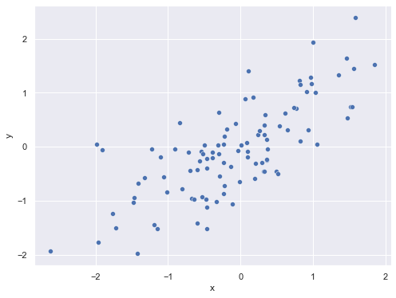

```python
sns.set(rc={"figure.figsize":(8, 6)})
_ = sns.scatterplot(x='x', y='y', data=df_1)
```

- Για τον υπολογισμό του συντελεστή Pearson χρησιμοποιούμε τη συνάρτηση `pearsonr()` από τη βιβλιοθήκη `scipy.stats.stats`.
- Η συνάρτηση επιστρέφει δύο τιμές: τον συντελεστή και την τιμή σημαντικότητάς του (p-value).

```python
stats.pearsonr(df_1.x, df_1.y)
```

```
(0.7529004259351295, 1.6598002643730582e-19)
```

- Ο συντελεστής Pearson μειώνεται όσο ξεφεύγουμε από τη γραμμική σχέση.
- Ας δούμε το παρακάτω παράδειγμα συνθετικών δεδομένων:

```python
np.random.seed(42)
r = 0.6
x = np.random.normal(size=100)
y = r*x + np.sqrt(1-r**2)*np.random.normal(size=100)
df_2 = pd.DataFrame({'x': x, 'y': y})
```

```python
df_2
```

|  | x | y |
| --- | --- | --- |
| 0 | 0.496714 | -0.834268 |
| 1 | -0.138264 | -0.419475 |
| 2 | 0.647689 | 0.114442 |
| 3 | 1.523030 | 0.271996 |
| 4 | -0.234153 | -0.269521 |
| ... | ... | ... |
| 95 | -1.463515 | -0.569855 |
| 96 | 0.296120 | -0.529414 |
| 97 | 0.261055 | 0.279613 |
| 98 | 0.005113 | 0.049635 |
| 99 | -0.234587 | -1.055129 |

100 rows × 2 columns

- Διαγραμματικά εμφανίζονται ως εξής:

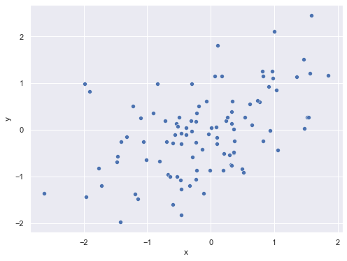

```python
_ = sns.scatterplot(x='x', y='y', data=df_2)
```

- Με αυτά τα δεδομένα παίρνουμε:

```python
stats.pearsonr(df_2.x, df_2.y)
```

```
(0.5038156484709347, 9.120853831670732e-08)
```

- Ο συντελεστής Pearson χρειάζεται προσοχή όταν τα δεδομένα μας έχουν έκτοπες τιμές (outliers), όπως [τα παρακάτω](https://upload.wikimedia.org/wikipedia/commons/6/67/Spearman_fig3.svg):

```python
np.random.seed(42)
r = 0.8
x = np.random.normal(size=100)
y = r*x + np.sqrt(1-r**2)*np.random.normal(size=100)
ii = np.argsort(-x)
x[ii[0:5]] *= 5
df_3 = pd.DataFrame({'x': x, 'y': y})
```

```python
df_3
```

|  | x | y |
| --- | --- | --- |
| 0 | 0.496714 | -0.451851 |
| 1 | -0.138264 | -0.362999 |
| 2 | 0.647689 | 0.312522 |
| 3 | 7.615149 | 0.737058 |
| 4 | -0.234153 | -0.284094 |
| ... | ... | ... |
| 95 | -1.463515 | -0.939622 |
| 96 | 0.296120 | -0.293418 |
| 97 | 0.261055 | 0.301079 |
| 98 | 0.005113 | 0.039016 |
| 99 | -0.234587 | -0.873452 |

100 rows × 2 columns

- Πράγματι, μπορούμε να δούμε τις έκτοπες τιμές στα δεξιά:

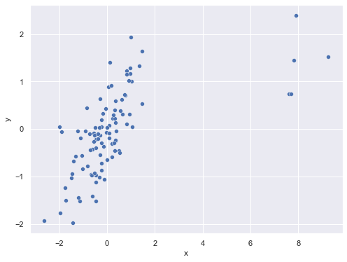

```python
_ = sns.scatterplot(x='x', y='y', data=df_3)
```

- Τότε παίρνουμε:

```python
stats.pearsonr(df_3.x, df_3.y)
```

```
(0.6200894823297651, 5.996001353052288e-12)
```

- Να θυμάστε ότι ο συντελεστής Pearson μετράει μια *γραμμική* συσχέτιση στα δεδομένα.
- Αυτό σημαίνει ότι τα δεδομένα μπορεί μεν να έχουν μια ξεκάθαρη σχέση, την οποία παρόλα αυτά δεν μπορεί να την εντοπίσει ο συντελεστής Pearson, όπως μπορείτε να δείτε στην [παρακάτω εικόνα](https://en.wikipedia.org/wiki/Pearson_correlation_coefficient#/media/File:Correlation_examples2.svg).

[figure not shown]

- Αν η συσχέτιση δεν είναι γραμμική, αλλά είναι εν τούτοις αύξουσα ή φθίνουσα, τότε μπορεί να είναι καταληλότερος ένας άλλος συντελεστής, ο συντελεστής συσχέτισης του Spearman.
- Ο συντελεστής αυτός συμβολίζεται με $\rho$ και μετρά πόσο καλά δύο μεταβλητές έχουν μια αύξουσα ή φθίνουσα (αλλά όχι απαραίτητα γραμμική) σχέση.
- Για τον υπολογισμό του συντελεστή Pearson χρησιμοποιούμε τη συνάρτηση `spearman()` από τη βιβλιοθήκη `scipy.stats.stats`, η οποία πάλι επιστρέφει τον συντελεστή και την τιμή σημαντικότητας.
- Έστω ότι τα δεδομένα μας είναι όπως [παρακάτω](https://commons.wikimedia.org/wiki/File:Spearman_fig1.svg):

$$ y = \operatorname{sgn}\left(\ln\frac{x}{1-x}\right) \left|\,\ln\frac{x}{1-x}\,\right|^{1{,}4} $$

```python
np.random.seed(42)
x = np.random.uniform(size=100)
y = np.log(x/(1-x))
y = np.sign(y)*(np.abs(y)**1.4)
df_4 = pd.DataFrame({'x': x, 'y': y})
```

```python
df_4
```

|  | x | y |
| --- | --- | --- |
| 0 | 0.374540 | -0.392567 |
| 1 | 0.950714 | 4.567958 |
| 2 | 0.731994 | 1.006674 |
| 3 | 0.598658 | 0.277140 |
| 4 | 0.156019 | -2.081504 |
| ... | ... | ... |
| 95 | 0.493796 | -0.005658 |
| 96 | 0.522733 | 0.034883 |
| 97 | 0.427541 | -0.178365 |
| 98 | 0.025419 | -6.118256 |
| 99 | 0.107891 | -2.849080 |

100 rows × 2 columns

- Μπορούμε να δούμε ότι τα δεδομένα έχουν μια γνησίως αύξουσα συσχέτιση, αλλά όχι γραμμική:

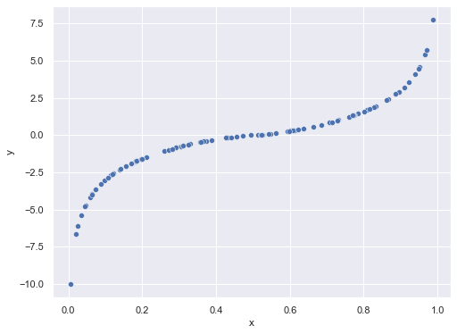

```python
_ = sns.scatterplot(x='x', y='y', data=df_4)
```

- Για να δούμε τι μας δίνουν οι συντελεστές Pearson και Spearman:

```python
print('Pearson', stats.pearsonr(df_4.x, df_4.y))
print('Spearman', stats.spearmanr(df_4.x, df_4.y))
```

```
Pearson (0.9154291577976971, 1.6129079055537388e-40)
Spearman SpearmanrResult(correlation=0.9999999999999999, pvalue=0.0)
```

- Ο συντελεστής Spearman μπορεί να είναι λιγότερο ευαίσθητος στις έκτοπες τιμές.
- Αν επιστρέψουμε στο σχετικό παράδειγμα:

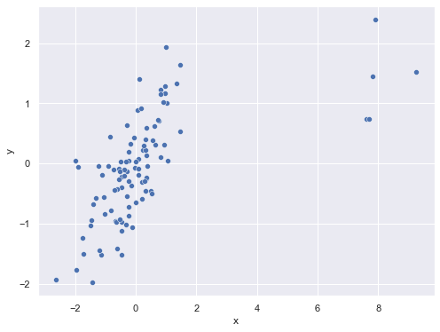

```python
_ = sns.scatterplot(x='x', y='y', data=df_3)
```

- Βλέπουμε ότι:

```python
print('Pearson', stats.pearsonr(df_3.x, df_3.y))
print(stats.spearmanr(df_3.x, df_3.y))
```

```
Pearson (0.6200894823297651, 5.996001353052288e-12)
SpearmanrResult(correlation=0.7201200120012, pvalue=3.0751702980521144e-17)
```

- Ας δούμε ένα άλλο παράδειγμα δεδομένων, από [ανάρτηση](http://www.thefunctionalart.com/2016/08/download-datasaurus-never-trust-summary.html) του [Alberto Cairo](http://albertocairo.com/).

```python
import pandas as pd

df_ac = pd.read_csv('the_functional_art.csv', header=None, names=['x', 'y'])
df_ac
```

|  | x | y |
| --- | --- | --- |
| 0 | 55.3846 | 97.1795 |
| 1 | 51.5385 | 96.0256 |
| 2 | 46.1538 | 94.4872 |
| 3 | 42.8205 | 91.4103 |
| 4 | 40.7692 | 88.3333 |
| ... | ... | ... |
| 137 | 39.4872 | 25.3846 |
| 138 | 91.2821 | 41.5385 |
| 139 | 50.0000 | 95.7692 |
| 140 | 47.9487 | 95.0000 |
| 141 | 44.1026 | 92.6923 |

142 rows × 2 columns

- Τα δεδομένα αυτά έχουν τις παρακάτω βασικές στατιστικές:

```python
df_ac.describe()
```

|  | x | y |
| --- | --- | --- |
| count | 142.000000 | 142.000000 |
| mean | 54.263273 | 47.832253 |
| std | 16.765142 | 26.935403 |
| min | 22.307700 | 2.948700 |
| 25% | 44.102600 | 25.288450 |
| 50% | 53.333300 | 46.025600 |
| 75% | 64.743600 | 68.525675 |
| max | 98.205100 | 99.487200 |

- Δεν φαίνεται να υπάρχει συσχέτιση μεταξύ των `x` και `y`:

```python
print('Pearson', stats.pearsonr(df_ac.x, df_ac.y))
print(stats.spearmanr(df_ac.x, df_ac.y))
```

```
Pearson (-0.06447185270095164, 0.44589659802470616)
SpearmanrResult(correlation=-0.06510904080429955, pvalue=0.44140461256177965)
```

- Είναι όμως πράγματι έτσι;

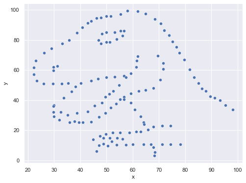

```python
_ = sns.scatterplot(x='x', y='y', data=df_ac)
```

- Συμπέρασμα: μη βασίζεστε μόνο στις μετρικές.
- Οπτικοποιήστε τα δεδομένα σας όσο μπορείτε κατά την ανάλυσή σας.